# Homework 9.28 황성윤

### Problem 1

Malnourishment in elderly patients is associated with an increasing risk of adverse clinical events and mortality, and an increasing length of hospital stay. Furthermore, persistent malnourishment can lead to deficiencies in various nutritional markers, including vitamin B12 and B6, and folate. O'Leary and collegues (2011) conducted a cross-sectional study of 52 patients aged ≥60 years who were admitted to a sub-acute geriatric rehailitation unit in Australia. The aim of the study was to examine association between the vitamin B12, B6 and folate, homocystein and methylmalonic acid (MMA), dietary intake, nutritional status and length of stay.

Length of stay was positively correlated with age and MMA (Spearman correlation coefficient ($r_{s}$) 0.4 $P<0.01$ and 0.28 $P<0.05$, respectively) and negatively correlated with albumin, vitamin B6 and the Mini Nutritional Assessment (MNA) score ($r_{s}$) -0.35, -0.33 and -0.29, respectively, and $P<0.05$ for each). When the authors compared subjects whose length of stay was <21 days to subjects whose length of stay was ≥21 days, those with longer of stay were on average, marginally older ($P=0.054$), had lower vitamin B6 ($P=0.025$) and lower serum folate concentrations ($P=0.035$) and had more B vitamin deficiencies ($P=0.026$) than those with shorter lengths of stay (Table 1)

#### `Table 1` Characteristics of subjects

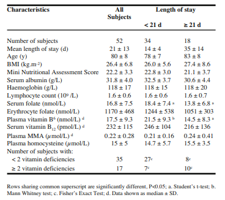

```python
from PIL import Image
Image.open('image_problem1.png')
```

#### `a)` Interpret the reported correlations between length of stay and age, MMA and albumin, as well as the results of any significance tests which relate to these correlation coefficient. When would it be most appropriate to display the Spearman correlation coefficient rather than the Pearson correlation coefficient when assessing the association between two values? Is there any evidence to suggest that this was appropriate in this situation?

- Spearman 상관계수 분석결과에 따르면 환자가 병원에 머무는 시간(length of stay)은 환자의 나이(age), 그리고 메틸말론산(MMA)의 수치와 유의한 양의 상관관계를 나타내고 있으며, 알부민(albumin), 비타민B6(vitamin B6), 그리고 영양평가점수(Mini Nutritional Assessment (MNA) score)와는 유의한 음의 상관관계를 나타내고 있다. Spearman 상관계수는 순위를 사용하기 때문에 자료에 있는 변수의 분포가 정규성을 만족한다고 보기 어려울 경우에 사용이 가능한 비모수적 통계방법이다. 이 때문에 정규성이 만족된다고 할 때 사용할 수 있는 Pearson 상관계수보다 사용할 수 있는 연구의 영역이 더 넓다.

#### `b)` Comment on the way in which the authors have chosen to present the P-values for these correlation coefficients.

- 상관계수 분석에 대한 P-value를 제시하는 방법은 양의 상관관계를 설명하고자 하는 경우와 음의 상관관계를 설명하고자 하는 경우로 나눌 수 있고 검정통계량은 $Z=\frac {r_{s}} {\sqrt{\frac {1}{n-1}}} \sim N(0,1^2)$ 이다. 만약 유의수준이 $\alpha=0.05$라고 한다면 검정 $H_{0} : r_{s}=0$ v.s $H_{0} : r_{s}>0$의 경우는 산출된 검정통계량의 값보다 더 큰 검정통계량을 얻을 확률이 0.05보다 작은 경우 해당하는 두 변수 사이에는 유의미한 양의 상관관계가 있다고 결론내리게 되며, 검정 $H_{0} : r_{s}=0$ v.s $H_{0} : r_{s}<0$의 경우는 산출된 검정통계량의 값보다 더 작은 검정통계량을 얻을 확률이 0.05보다 작은 경우 해당하는 두 변수 사이에는 유의미한 음의 상관관계가 있다고 결론내리게 된다.

#### `c)` For most of the variables shown in Table 1, the authors chose to present mean values with SDs. For three variables (plasma vitamin B6, serum vitamin B12 and plasma MMA), however, the authors presented medians with standard deviations. Why do you think they presented medians instead of means for these variables? Comments on the appropriateness of presenting standard deviations for these three variables. Finally, comment on the appropriateness of presenting mean values for the other variables in Table 1, particularly length of stay. What further information would you like to see to help you answer this question?

- 필자가 보기에 연구자가 플라즈마 비타민 B6, 세럼 비타민 B12, 그리고 플라즈마 MMA 같은 요인에 대해 평균이 아닌 중앙값을 이용한 신뢰구간을 제시한 이유는 아마도 이 세가지 요인에 대해 이상치 등이 존재하여 이에 대한 영향을 많이 받는 평균을 가지고는 제대로 된 분석을 수행하기 어렵다고 판단을 해서 그러지 않았을까 싶다. 모중앙값에 대한 신뢰구간은 t분포를 이용하여 근사적으로 표현할 수 있으며 표준편차는 모평균과 동일하게 표본표준편차를 표본의 수의 제곱근값으로 나눈 $\frac {s}{\sqrt{n}}$으로 표현하면 된다. 그리고 환자가 병원에 머무는 시간은 이상치가 나타날 가능성이 그래도 작다고 보여지므로 중앙값보다는 평균을 이용하여 신뢰구간을 나타내는 것이 바람직하다고 생각한다.

#### `d)` The authors compared subjects who were hospitalised for <21 days with those hospitalised for ≥21 days. What test(s) would they have used to make comparisons of any numerical variables in Table 1? Give reasons for your answers.

- 두가지 집단 (<21 days)와 (≥21 days)를 비교하기 위해서는 각 Table 1 에 주어진 각 항목의 수치에 대한 표본평균을 가지고 Student's t-test를 수행하는 것이 일반적이다. 하지만 이 방법은 모집단의 분포가 정규성을 따른다는 근거가 있을 경우에 더 검정력이 높고 그렇지 않은 경우에는 잘못된 결과를 나타낼 수 있다. 만약 이러한 근거가 없을 경우에는 비모수적 방법인 Mann Whitney test를 수행하여 검정을 실시할 수 있다.

### Problem 2

It has been reported that older individuals experiencing severe burns have a higher mortality rate than younger individuals with severe burns. To asseess whether any differences in mortality can explained by differences in demographic or clinical characteristics of older and younger individuals. Albornoz and colleagures (2011) described a case-control study of 66 patients aged 65 years or older (case: over-65 group) and 22 patients younger than 65 years (control: under-65 years) who were admitted with severe burns to the intermediate and intensive care unit of the National Burn Adult Reference Centre in Santiago, Chile. The investigators collected information on the burn agent (eg. fire or scald), whether inhalation injuries were present, the burn surface area expressed as a percentage of the total body surface area (%TBSA), the deep burn surface area, also expressed as a percentage (%DTBSA), the DTBSA:TBSA proportion and the primary outcomes of the study were the length of stay in the intensive care unit and mortality.

A summary of the characteristics of patients in the two groups is shown in Table 2. In unadjusted analyses, the mortality rate was significantly higher in the over-65 group (odds ratio 2.9, 95% confidence interval 1.6-5.2, $P<0.001$); after controlling for other potential confounders in a multivariable logistic regression analysis, those aged ≥65 years were over 12 times more likely to die from their burn than those in the younger age group (adjusted odds ratio 12.02, $P<0.001$). The adjusted odds ratio for %TBSA was 1.06 per unit increment ($P<0.001$), where as that for the DTBSA:TBSA proportion was 7.6 per unit increment ($P<0.001$). After adjustment using a multivariable logistic regression analysis, there were no significant associations between mortality and gender, the presence of inhalation injuries or any other comobidities (eg. epilepsy, obesity, smoking or cardiovascular disease).

#### `Table 2` Summary of main characteristics of the over-65 and under-65 groups.

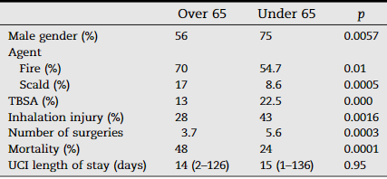

```python
Image.open('image_problem2.png')
```

#### `a)` Explain why the study cannot be decribed as a case-control study. What would be a more appropriate description of the study design?

- 사례-대조 연구(case-control study)는 후향적 연구로서 사례군과 대조군을 정의하고 위험요인을 역추적하여 평가하는 연구설계방법이다. 본 연구에서의 관심사건은 심한 화상(severe burns)을 입은 환자가 사망하는 비율이고 환자가 사망하는 사건은 앞으로 시간을 두고 관찰을 해야 접할 수 있다. 따라서 이 경우에는 동일한 대상을 가지고 코호트 구성 및 위험요인을 평가하고 추적하여 결과를 관찰하는 전향적 연구인 코호트 연구(cohort study)를 수행하는 것이 더 바람직하다고 보여진다.

#### `b)` Comment on the distributions of the numerical variables summarised in Table 2. Do you agree with the authors' choice of summary measures for each variable? If not, what are your reasons for this and what summary measure would you choose to present instead?

- Table 2를 보면 두가지 집단(Over 65, Under 65)에 대해 일부의 변수에 대해서는 해당하는 환자의 비율(%)로서 분포를 표시하고 있다. 이렇게 해도 크게 나쁠것 같지는 않아 보이지만, 만약 필자가 이 연구를 수행한다면 비율보다는 각각의 변수에 대해 해당하는 사람의 수를 그대로 표기하고 각 집단에 대해 몇명의 환자를 조사했는지 추가로 덧붙여서 결과를 제시할 것 같다.

#### `c)` Using the data provided in Table 2, demonstrate how the authors would have calculated the unadjusted odds ratio for mortality?

- Table 2에 있는 자료를 바탕으로 Mortality에 대한 분할표를 실제 환자수를 이용하여 만들어보면 다음과 같을 것으로 예상된다. 사실 비율(%)만 표기되어 있기 때문에 정확한 자료를 찾기에는 무리가 따른다. 따라서 실제로 연구자가 계산한 값과 필자가 계산한 값에는 약간의 차이가 있을수도 있음을 밝혀둔다.

[output not shown]